# Your Digest for Monday, Feb 12, 2024 11:59 PM

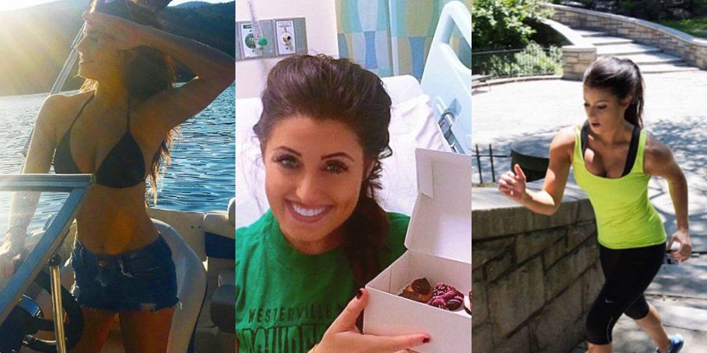

> " In February of 2015, after a busy weekend, *I began feeling some tingling in the bottom of my feet*. I thought that I was just sore from wearing heels, *but within a few days, the numbness and tingling proceeded to go up my shins and into my knees* and through my thighs"  
> [Source](https://www.womenshealthmag.com/health/g19948080/ms-at-age-25/)
> - chronic T cell-mediated autoimmune disorder characterised by demyelination in the central nervous system with multiple *plaques of demyelination* found throughout the **brain and spinal cord**
> - **Peripheral myelinated nerves are NOT affected.**
> - 3 times more common in women
> - most commonly diagnosed in people aged 20-40 years
> - Relapsing remitting disease is the most common form with acute attacks lasting 1-2 months with remissions.
>   - Relapses are caused by acute inflammation causing myelin damage and conduction block.
> - around 65% of patients with relapsing-remitting disease go on to develop secondary progressive disease within 15 years of diagnosis.
>   - That means -> development of permanent neurologic deficits:
>   - **gait and bladder disorders** are generally seen
> - Primary progressive disease is commoner in older people
- Demyelination has a prediliction of **cervical** spinal cord, optic nerves, corpus callosum, cerebellar connections of the brainstem. (contrast with PML where spinal cord and optic nerves are spared)

**Symptoms**:

- *Paraesthesia* is an early complaint.
- *Spasticity*
- *Autonomic*: bladder / bowel and sexual dysfunction.
- Cerebellar: **charcot triad** -> Scanning speech, *nystagmus* and intention *tremmor*.
- [[Ophthalmologic diseases#Optic neuritis|Optic neuritis]] : (classic presentation -> **unilateral, moderate, painful vision loss** with afferent pupillary defect and normal fundus examination.
- Depression
- [[General medicine 6-Neurology#Trigeminal neuralgia|Trigeminal Neuralgia]]

**Investigations**:

- MRI
- CSF - "oligoclonal bands" and intrathecal IgG production.
- Evoked potentials - Non specific.

**Management**:

- No cure
- Symptomatic treatment for various system involvement.
  - Incontinence: USS is essential to assess residual bladder volume to exclude overflow incontinence as oxybutinin may worsen symptoms if prescribed before USS assessment)
- Disease modifying drugs:
  - **natalizumab** - monoclonal antibody which inhibits leukocyte migration across the blood brain barrier. - IV
  - **ocrelizumab** - IV
  - Fingolimod - sphongosine receptor modulator
  - Two older drugs
    - beta interferon - considered to be not as efective.
    - glatiramer acetate - immune decoy - reduced relapse frequency and reduce development of new MRI lesions. Given Sub cut or IM.
  - Oral disease modifying drugs are also available.

# Haemostasis

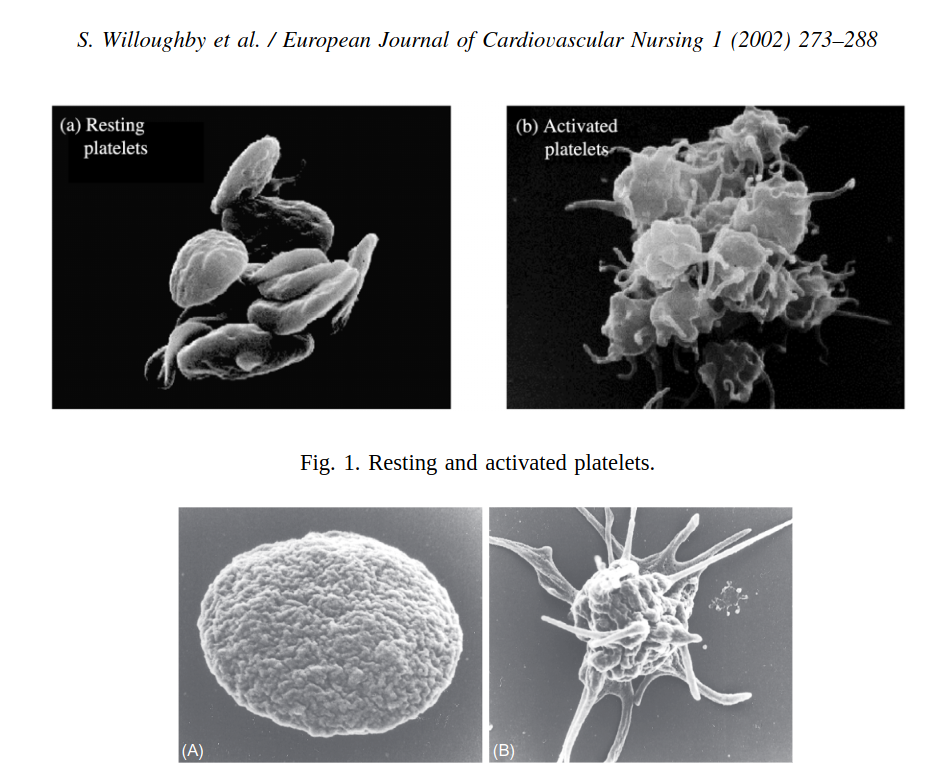

1. The quickest response to endothelial damage is formation of the platelet plug. Platelets roll off the exposed collagen and stick to it.

> [!INFO] Platelet activation and aggregation

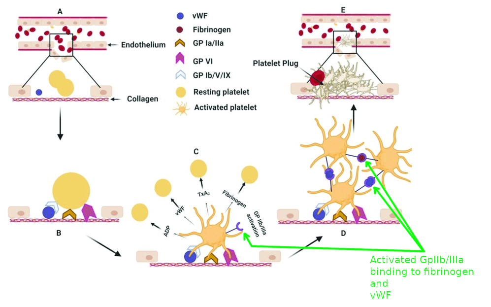

> Adhesion, activation and aggregation. (A) Endothelial injury in the blood vessel exposes collagen to platelets and von Willebrand factors (vWF). (B) Resting platelets attach to the exposed collagen with their glycoprotein surface receptors directly and/or via vWF mediated anchorage. (C) The platelet, upon adhesion to collagen, is activated, changes morphology and releases granular contents which activate more platelets. **Activated platelets induce conformational change in a surface receptor, namely, glycoprotein receptor (GP)IIb/IIIa, which induces (D) platelet aggregation via vWF and fibrinogen**. (E) Aggregated platelets form a plug at the site of the injury, thereby stopping the blood leakage temporarily. ADP: Adenosine diphosphate; TxA 2 : Thromboxane A 2 ; vWF: von Willebrand factor; GP: glycoprotein receptors. (Figure courtesy of biorender.com).

> [!INFO] How to visualize what platelet 'aggregation' means  
> Prostaglandins influence intra platelet calcium via cAMP;  
> **Ca2+ is required for the processes which produce platelet aggregation and adhesion**.
- prostacylin reduces platelet calcium.
- Thromboxane increases platelet calcium.